# Binary Classification for e-nose air-quality data

This is a test to check if binary classification is possible for pollution dataset using electronic sensor heads.

Classifying absolute humidity is not very interesting, yet it’s the variable that we chose in project 1 and for now we will stick to it.

Multi-colinearity issues may arise due to highly correlated variables. Eliminating some variables will weaken our classification study. Professor said that we do a logistic reg using PCs.

Other possible binary variables to create: One might consider predicting whether it’s a rush hour or not. One might also Predict absence or presence of a certain chemical compound in the air due to sensor responses

```r
################################################################################

# Standardize dataframe function

standardizeDF <- function(x) {

  new_columns = c()

  for (name in names(x)) {
    new_col = (x[name]-mean(as.matrix(x[name])))/sd(as.matrix(x[name]))
    new_columns = append(new_columns, new_col, after=length(new_columns))
  }

  return(data.frame(new_columns))
}

################################################################################
```

```r
air_quality_data = read.table('cleanAirQuality.csv', sep=";",
                              header=TRUE, stringsAsFactors=TRUE)

AH_bin_factor <- as.factor(air_quality_data[['AH_bin']])

# date_filter = subset (air_quality_data, select = c(Date))

air_quality_data = subset (air_quality_data, select = c(-AH_bin, -Date, -Time))
air_quality_data = standardizeDF(air_quality_data)

air_quality_data = append(air_quality_data, data.frame(AH_bin_factor), after = length(air_quality_data))

air_quality_data = data.frame(air_quality_data)

summary(air_quality_data)
```

```
     CO.GT.         PT08.S1.CO.         NMHC.GT.          C6H6.GT.       PT08.S2.NMHC.
 Min.   :-1.4297   Min.   :-1.6680   Min.   :-1.1544   Min.   :-1.3126   Min.   :-1.83297
 1st Qu.:-0.7705   1st Qu.:-0.8197   1st Qu.:-0.7512   1st Qu.:-0.7647   1st Qu.:-0.76117
 Median :-0.1845   Median :-0.1134   Median :-0.2772   Median :-0.1887   Median :-0.04185
 Mean   : 0.0000   Mean   : 0.0000   Mean   : 0.0000   Mean   : 0.0000   Mean   : 0.00000
 3rd Qu.: 0.4746   3rd Qu.: 0.6711   3rd Qu.: 0.4321   3rd Qu.: 0.5418   3rd Qu.: 0.66693
 Max.   : 4.2832   Max.   : 3.3643   Max.   : 4.1969   Max.   : 4.1103   Max.   : 3.13619
    NOx.GT.         PT08.S3.NOx.        NO2.GT.          PT08.S4.NO2.      PT08.S5.O3.
 Min.   :-1.5487   Min.   :-1.8355   Min.   :-2.48052   Min.   :-1.8452   Min.   :-1.78609
 1st Qu.:-0.7437   1st Qu.:-0.7236   1st Qu.:-0.64842   1st Qu.:-0.7587   1st Qu.:-0.69276
 Median :-0.1789   Median :-0.2331   Median :-0.06826   Median :-0.1129   Median :-0.09574
 Mean   : 0.0000   Mean   : 0.0000   Mean   : 0.00000   Mean   : 0.0000   Mean   : 0.00000
 3rd Qu.: 0.5450   3rd Qu.: 0.5468   3rd Qu.: 0.70275   3rd Qu.: 0.5621   3rd Qu.: 0.65329
 Max.   : 4.0507   Max.   : 3.3501   Max.   : 2.83256   Max.   : 3.9196   Max.   : 3.45777
       T                  RH          AH_bin_factor
 Min.   :-1.84955   Min.   :-2.4473   0:260
 1st Qu.:-0.75765   1st Qu.:-0.8108   1:240
 Median :-0.07799   Median : 0.1327
 Mean   : 0.00000   Mean   : 0.0000
 3rd Qu.: 0.55709   3rd Qu.: 0.7595
 Max.   : 3.32027   Max.   : 2.3089
```

We first try the logistic regression framework. We split the data into 80/20 ratio.

```r
# AH_bin = as.factor(AH_bin)
set.seed(1)
sample <- sample(c(TRUE, FALSE), dim(air_quality_data)[1], replace=TRUE, prob=c(0.8,0.2))
train  <- air_quality_data[sample, ]
test   <- air_quality_data[!sample, ]
```

```r
GLM1 <- glm(formula = AH_bin_factor ~ .,data = train, family=binomial(logit))
summary(GLM1)
```

```
Call:
glm(formula = AH_bin_factor ~ ., family = binomial(logit), data = train)

Deviance Residuals:
     Min        1Q    Median        3Q       Max
-2.47414  -0.01788   0.00000   0.02271   3.13296

Coefficients:
              Estimate Std. Error z value Pr(>|z|)
(Intercept)    -1.7990     0.4670  -3.853 0.000117 ***
CO.GT.          0.7303     2.1715   0.336 0.736631
PT08.S1.CO.     1.1098     1.4173   0.783 0.433591
NMHC.GT.        1.0802     0.7955   1.358 0.174512
C6H6.GT.       -1.4765     3.9594  -0.373 0.709211
PT08.S2.NMHC. -17.0404     5.3012  -3.214 0.001307 **
NOx.GT.        -3.2549     1.3465  -2.417 0.015636 *
PT08.S3.NOx.   -4.7684     2.0480  -2.328 0.019895 *
NO2.GT.         0.7401     1.0379   0.713 0.475814
PT08.S4.NO2.   14.5423     3.4762   4.183 2.87e-05 ***
PT08.S5.O3.     1.1923     1.1997   0.994 0.320317
T              11.1838     2.0793   5.379 7.51e-08 ***
RH             12.6162     2.4362   5.179 2.23e-07 ***
---
Signif. codes:  0 ‘***’ 0.001 ‘**’ 0.01 ‘*’ 0.05 ‘.’ 0.1 ‘ ’ 1

(Dispersion parameter for binomial family taken to be 1)

    Null deviance: 561.249  on 404  degrees of freedom
Residual deviance:  75.013  on 392  degrees of freedom
AIC: 101.01

Number of Fisher Scoring iterations: 9
```

```r
ppv=1-pchisq(314.3-57.34, df=404-392)
ppv
```

```
[1] 0
```

```r
glm0 <- glm(AH_bin_factor ~ 1, data = train,family=binomial(link="logit"))
anova(glm0, GLM1, test="Chisq")
```

```
Analysis of Deviance Table

Model 1: AH_bin_factor ~ 1
Model 2: AH_bin_factor ~ CO.GT. + PT08.S1.CO. + NMHC.GT. + C6H6.GT. +
    PT08.S2.NMHC. + NOx.GT. + PT08.S3.NOx. + NO2.GT. + PT08.S4.NO2. +
    PT08.S5.O3. + T + RH
  Resid. Df Resid. Dev Df Deviance  Pr(>Chi)
1       404     561.25
2       392      75.01 12   486.24 < 2.2e-16 ***
---
Signif. codes:  0 ‘***’ 0.001 ‘**’ 0.01 ‘*’ 0.05 ‘.’ 0.1 ‘ ’ 1
```

If we analyse a bit the full raw model

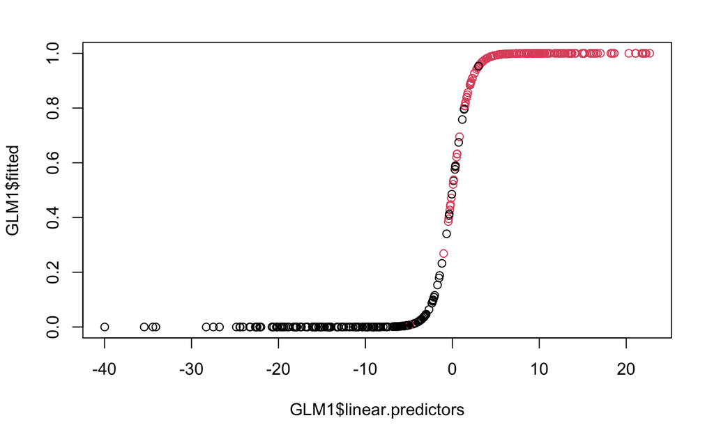

```r
plot(GLM1$linear.predictors, GLM1$fitted, col = as.numeric(train[['AH_bin_factor']]))
```

```r
Classif1 <- glm2$fitted.values >= 0.5
(tab <- table(train[['AH_bin_factor']], Classif1))
```

[output not shown]

```r
library(MASS)
stepAIC(GLM1, direction="backward")
```

```
Start:  AIC=101.01
AH_bin_factor ~ CO.GT. + PT08.S1.CO. + NMHC.GT. + C6H6.GT. +
    PT08.S2.NMHC. + NOx.GT. + PT08.S3.NOx. + NO2.GT. + PT08.S4.NO2. +
    PT08.S5.O3. + T + RH
```

```
                Df Deviance     AIC
- CO.GT.         1   75.128  99.128
- C6H6.GT.       1   75.153  99.153
- NO2.GT.        1   75.525  99.525
- PT08.S1.CO.    1   75.633  99.633
- PT08.S5.O3.    1   76.016 100.016
- NMHC.GT.       1   76.918 100.918
<none>               75.013 101.013
- NOx.GT.        1   81.649 105.649
- PT08.S3.NOx.   1   82.128 106.128
- PT08.S2.NMHC.  1   89.005 113.005
- PT08.S4.NO2.   1  106.600 130.600
- RH             1  153.751 177.751
- T              1  160.962 184.962
```

```
Step:  AIC=99.13
AH_bin_factor ~ PT08.S1.CO. + NMHC.GT. + C6H6.GT. + PT08.S2.NMHC. +
    NOx.GT. + PT08.S3.NOx. + NO2.GT. + PT08.S4.NO2. + PT08.S5.O3. +
    T + RH
```

```
                Df Deviance     AIC
- C6H6.GT.       1   75.204  97.204
- NO2.GT.        1   75.832  97.832
- PT08.S5.O3.    1   76.030  98.030
- PT08.S1.CO.    1   76.153  98.153
<none>               75.128  99.128
- NMHC.GT.       1   77.384  99.384
- NOx.GT.        1   81.660 103.660
- PT08.S3.NOx.   1   82.410 104.410
- PT08.S2.NMHC.  1   89.462 111.462
- PT08.S4.NO2.   1  107.091 129.091
- RH             1  156.101 178.101
- T              1  169.005 191.005
```

```
Step:  AIC=97.2
AH_bin_factor ~ PT08.S1.CO. + NMHC.GT. + PT08.S2.NMHC. + NOx.GT. +
    PT08.S3.NOx. + NO2.GT. + PT08.S4.NO2. + PT08.S5.O3. + T +
    RH
```

```
                Df Deviance     AIC
- PT08.S5.O3.    1   76.030  96.030
- NO2.GT.        1   76.101  96.101
- PT08.S1.CO.    1   76.396  96.396
<none>               75.204  97.204
- NMHC.GT.       1   77.392  97.392
- NOx.GT.        1   81.661 101.661
- PT08.S3.NOx.   1   97.899 117.899
- PT08.S4.NO2.   1  118.396 138.396
- PT08.S2.NMHC.  1  118.541 138.541
- RH             1  160.706 180.706
- T              1  172.202 192.202
```

```
Step:  AIC=96.03
AH_bin_factor ~ PT08.S1.CO. + NMHC.GT. + PT08.S2.NMHC. + NOx.GT. +
    PT08.S3.NOx. + NO2.GT. + PT08.S4.NO2. + T + RH
```

```
                Df Deviance     AIC
- NO2.GT.        1   77.093  95.093
- NMHC.GT.       1   77.891  95.891
<none>               76.030  96.030
- PT08.S1.CO.    1   78.951  96.951
- NOx.GT.        1   81.702  99.702
- PT08.S3.NOx.   1  104.401 122.401
- PT08.S4.NO2.   1  121.864 139.864
- PT08.S2.NMHC.  1  124.550 142.550
- RH             1  161.431 179.431
- T              1  172.789 190.789
```

```
Step:  AIC=95.09
AH_bin_factor ~ PT08.S1.CO. + NMHC.GT. + PT08.S2.NMHC. + NOx.GT. +
    PT08.S3.NOx. + PT08.S4.NO2. + T + RH
```

```
                Df Deviance     AIC
<none>               77.093  95.093
- NMHC.GT.       1   79.143  95.143
- PT08.S1.CO.    1   81.602  97.602
- NOx.GT.        1   81.952  97.952
- PT08.S3.NOx.   1  111.056 127.056
- PT08.S2.NMHC.  1  125.009 141.009
- PT08.S4.NO2.   1  125.485 141.485
- RH             1  176.453 192.453
- T              1  196.123 212.123

Call:  glm(formula = AH_bin_factor ~ PT08.S1.CO. + NMHC.GT. + PT08.S2.NMHC. +
    NOx.GT. + PT08.S3.NOx. + PT08.S4.NO2. + T + RH, family = binomial(logit),
    data = train)

Coefficients:
  (Intercept)    PT08.S1.CO.       NMHC.GT.  PT08.S2.NMHC.        NOx.GT.   PT08.S3.NOx.   PT08.S4.NO2.
       -1.629          2.207          1.043        -18.056         -2.428         -5.815         13.647
            T             RH
       11.377         12.688

Degrees of Freedom: 404 Total (i.e. Null);  396 Residual
Null Deviance:      561.2
Residual Deviance: 77.09    AIC: 95.09
```